# CMap Drug Safety Challenge: Gene test across samples of HEPG2, 10 µM and 6 h

Joaquim Aguirre-Plans

April 29, 2019

## Load files

First we load the R objects needed.

```r
load(drugs_file)
load(drug_info_file)
load(dilirank_file)
load(expression_file) # Requires cmapR
```

We load the gene information file as well, containing the landmark genes [More info](https://clue.io/connectopedia/l1000_gene_space).

```r
gene_info_df <- read.csv(gene_info_file, header=TRUE, sep="\t")
landmark_genes <- gene_info_df$pr_gene_id[gene_info_df$pr_is_lm==1]
```

I subset the DILIConcern data by those drugs that have the same label in the columns DILIConcern and vDILIConcern.

```r
drank.sel$DILIConcern[drank.sel$DILIConcern == "No-DILI-concern"] <- "No-DILI-Concern" # Correct the 4 entries with lowercase concern
# We remove the first letter from vDILIConcern entries (except Ambiguous)
drank.sel$vDILIConcern[drank.sel$vDILIConcern != "Ambiguous DILI-concern"] <- sub('.', '', drank.sel$vDILIConcern[drank.sel$vDILIConcern != "Ambiguous DILI-concern"])
# We subset the table by those drugs that have the same value in vDILIConcern and DILIConcern columns
dilirank_df <- drank.sel[drank.sel$vDILIConcern == drank.sel$DILIConcern,]
most_concern_drugs <- dilirank_df$pert_iname[dilirank_df$DILIConcern == "Most-DILI-Concern"]
less_concern_drugs <- dilirank_df$pert_iname[dilirank_df$DILIConcern == "Less-DILI-Concern"]
no_concern_drugs <- dilirank_df$pert_iname[dilirank_df$DILIConcern == "No-DILI-Concern"]
```

We have 175 compounds:

- Most-DILI-Concern: 37
- Less-DILI-Concern: 87
- No-DILI-Concern: 51

```r
# Subset the GCT object by Most-DILI-Concern drugs
id_most <- which(gct@cdesc$pert_iname %in% most_concern_drugs)
gct_most <- subset.gct(gct, cid=id_most)
# Subset the GCT object by No-DILI-Concern drugs
id_no <- which(gct@cdesc$pert_iname %in% no_concern_drugs)
gct_no <- subset.gct(gct, cid=id_no)
```

## Compare the expression of each gene across samples of Most-DILI-Concern vs. No-DILI-Concern in HEPG2 cell line, 10 µM and 6 h

We will use the samples from the HEPG2 cell line, which is the only liver cell line in CMap available in this dataset ([More info](https://clue.io/connectopedia/core_cmap_cell_panel)).

```r
# Subset the samples from Most-DILI-Concern drugs by HEPG2
id_most_hep <- which(gct_most@cdesc$cell_id == "HEPG2")
gct_most_hep <- subset.gct(gct_most, cid=id_most_hep)
# Subset the samples from No-DILI-Concern drugs by HEPG2
id_no_hep <- which(gct_no@cdesc$cell_id == "HEPG2")
gct_no_hep <- subset.gct(gct_no, cid=id_no_hep)
```

Among samples from Most-DILI-Concern drugs, there are 78 HEPG2 samples. These samples have different doses and times:

```r
table(gct_most_hep@cdesc$pert_idose, gct_most_hep@cdesc$pert_itime)
```

```
##
##           24 h 6 h
##   0.04 µM    2   0
##   0.12 µM    2   0
##   0.37 µM    2   0
##   1.11 µM    2   0
##   10 µM      2  64
##   100 µM     0   1
##   3.33 µM    2   0
##   30 µM      0   1
```

Same happens with No-DILI-Concern drugs, with 140 HEPG2 samples in different doses and times:

```r
table(gct_no_hep@cdesc$pert_idose, gct_no_hep@cdesc$pert_itime)
```

```
##
##           24 h 6 h
##   0.04 µM    5   0
##   0.12 µM    5   0
##   0.37 µM    5   0
##   1 µM       0   1
##   1.11 µM    5   0
##   10 µM      7 105
##   3 µM       1   1
##   3.33 µM    5   0
```

We will use 10 µM and 6 h, as it is clearly the condition with more samples in both cases.

```r
# Subset the samples from Most-DILI-Concern drugs by HEPG2, 10 µM and 6 h
id_most_hep_10_6 <- which(gct_most_hep@cdesc$pert_idose == "10 µM" & gct_most_hep@cdesc$pert_itime == "6 h")
gct_most_hep_10_6 <- subset.gct(gct_most_hep, cid=id_most_hep_10_6)
# Subset the samples from No-DILI-Concern drugs by HEPG2, 10 µM and 6 h
id_no_hep_10_6 <- which(gct_no_hep@cdesc$pert_idose == "10 µM" & gct_no_hep@cdesc$pert_itime == "6 h")
gct_no_hep_10_6 <- subset.gct(gct_no_hep, cid=id_no_hep_10_6)
```

Now, for each gene, we will check the difference of expression between Most-DILI-Concern drugs and No-DILI-Concern drugs using a Wilcoxon rank-sum test (or Mann-Whitney U test) ([More info](https://stat.ethz.ch/R-manual/R-devel/library/stats/html/wilcox.test.html)).

```r
# Create new dataframe to store the results
cols <- c("gene_id", "landmark", "statistic", "p.value")
wilcox_df <- data.frame(matrix(ncol = length(cols), nrow=0))
colnames(wilcox_df) <- cols

# Calculate the wilcoxon for each gene and store the results
output_table <- "/home/quim/PHD/Projects/camda/results/gene_test_hep_10_6.tsv"
if(!file.exists(output_table)){
  for (gene_id in gct_most_hep_10_6@rid) {
    most_expr <- gct_most_hep_10_6@mat[gct_most_hep_10_6@rid == gene_id]
    no_expr <- gct_no_hep_10_6@mat[gct_no_hep_10_6@rid == gene_id]
    res <- wilcox.test(most_expr, no_expr, alternative = "two.sided", paired = FALSE)
    landmark <- gene_id %in% landmark_genes
    wilcox_df[nrow(wilcox_df)+1,] <- c(gene_id, landmark, res$statistic, res$p.value)
  }
  wilcox_df$p.value <- as.numeric(wilcox$p.value)
  wilcox_df$p.adjust <- p.adjust(wilcox_df$p.value, "BH")
  write.table(wilcox_df, file = output_table,row.names=FALSE, na="-",col.names=TRUE, sep="\t")
}else{
  wilcox_df = read.csv(output_table, header = TRUE, sep = "\t")
}
head(wilcox_df)
```

```
##   gene_id landmark statistic    p.value p.adjust
## 1    5720     TRUE      3294 0.83188336        1
## 2     466     TRUE      4033 0.02928824        1
## 3    6009     TRUE      3752 0.20449143        1
## 4    2309     TRUE      4000 0.03820660        1
## 5     387     TRUE      3028 0.28264449        1
## 6    3553     TRUE      3321 0.90069834        1
```

Among the 12328 genes, there are 0 genes with an adjusted p-value under 0.05 and 0 under 0.01.

We will make a heatmap to plot the expression of the genes for each drug.

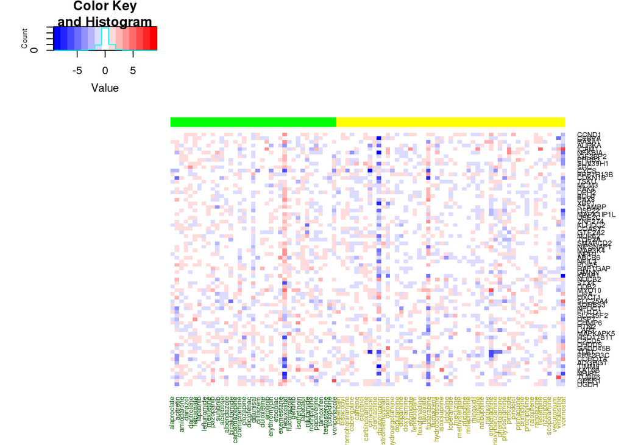

```r
# Define the genes found
all_wilcox_gene_ids <- unique(wilcox_df$gene_id[wilcox_df$p.value<0.01])
landmark_wilcox_gene_ids <- unique(wilcox_df$gene_id[wilcox_df$p.value<0.01 & wilcox_df$landmark==TRUE])

# Get a vector of gene symbols ordered equal to the vector of gene IDs
genes_selected <- landmark_wilcox_gene_ids
genes_df <- data.frame(1:length(genes_selected), genes_selected)
colnames(genes_df)<- c("id", "pr_gene_id")
genes_df <- merge(genes_df, gene_info_df[,c("pr_gene_id", "pr_gene_symbol")], by="pr_gene_id")
genes_df <- genes_df[order(genes_df$id), ]
genes_df$id <- NULL

# Create new dataframe to store the matrix
cols <- c(most_concern_drugs, no_concern_drugs)
rows <- genes_df$pr_gene_symbol
heat_df <- data.frame(matrix(ncol = length(cols), nrow=length(rows)))
colnames(heat_df) <- cols
rownames(heat_df) <- rows
gene_ids <- genes_df$pr_gene_id

# Introduce the data in the matrix
for (drug in most_concern_drugs){
  id_drug <- which(gct_most_hep_10_6@cdesc$pert_iname == drug)
  id_genes <- which(gct_most_hep_10_6@rid %in% gene_ids)
  gct_drug <- subset.gct(gct_most_hep_10_6, cid=id_drug, rid=id_genes)
  #means<- rowMeans(gct_drug@mat)
  medians <- apply(gct_drug@mat, 1, median)
  heat_df[drug] <- medians
}
for (drug in no_concern_drugs){
  id_drug <- which(gct_no_hep_10_6@cdesc$pert_iname == drug)
  id_genes <- which(gct_no_hep_10_6@rid %in% gene_ids)
  gct_drug <- subset.gct(gct_no_hep_10_6, cid=id_drug, rid=id_genes)
  #means<- rowMeans(gct_drug@mat)
  medians <- apply(gct_drug@mat, 1, median)
  heat_df[drug] <- medians
}
#heatmap(as.matrix(heat_df), Colv = NA, Rowv = NA, scale="column")
#heatmap.2(as.matrix(heat_df), col=bluered, Colv = NA, Rowv = NA, scale="row", trace="none")
#heatmap.2(as.matrix(heat_df), col=bluered, Colv = NA, Rowv = NA, scale="none", trace="none") #no scale means we use the raw z-scores
cc <- c(rep("green", times=length(most_concern_drugs)), rep("yellow", times=length(no_concern_drugs)))
cc2 <- c(rep("#004f00", times=length(most_concern_drugs)), rep("#9a9a00", times=length(no_concern_drugs)))
heatmap.2(as.matrix(heat_df), col=bluered, Colv = NA, Rowv = NA, scale="none", trace="none", ColSideColors=cc, colCol=cc2) #no scale means we use the raw z-scores
```

We will read the file containing the DisGeNET genes for each DILI-related phenotype:

```r
phenotype2gene <- read.csv(phenotype2gene_file, header=TRUE, sep="\t")
```

We will check the overlap between DisGeNET genes and the genes identified by the Wilcoxon test for each DILI-related phenotype:

```r
# Define the phenotypes
phenotypes <- unique(phenotype2gene$diseaseid)
curated_phenotypes <- unique(phenotype2gene$diseaseid[phenotype2gene$source == "CURATED"])

# Create new dataframe to store the results
cols <- c("phenotype", "source", "landmark", "cutoff", "intersection")
intersect_df <- data.frame(matrix(ncol = length(cols), nrow=0))
colnames(intersect_df) <- cols

# Check the intersection between the genes found by wilcoxon and by DisGeNET
for (phenotype in phenotypes){
  curated_gene_ids <-unique(phenotype2gene$geneid[phenotype2gene$diseaseid==phenotype & phenotype2gene$source=="CURATED"])
  all_gene_ids <- unique(phenotype2gene$geneid[phenotype2gene$diseaseid==phenotype & phenotype2gene$source=="ALL"])
  intersect_df[nrow(intersect_df)+1,] <- c(phenotype, "CURATED", FALSE, 0.01, length(intersect(all_wilcox_gene_ids, curated_gene_ids)))
  intersect_df[nrow(intersect_df)+1,] <- c(phenotype, "ALL", FALSE, 0.01, length(intersect(all_wilcox_gene_ids, all_gene_ids)))
  intersect_df[nrow(intersect_df)+1,] <- c(phenotype, "CURATED", TRUE, 0.01, length(intersect(landmark_wilcox_gene_ids, curated_gene_ids)))
  intersect_df[nrow(intersect_df)+1,] <- c(phenotype, "ALL", TRUE, 0.01, length(intersect(landmark_wilcox_gene_ids, all_gene_ids)))
}

output_table <- "/home/quim/PHD/Projects/camda/results/gene_test_hep_10_6_intersection.tsv"
write.table(intersect_df, file = output_table,row.names=FALSE, na="-",col.names=TRUE, sep="\t")
head(intersect_df)
```

```
##   phenotype  source landmark cutoff intersection
## 1  C0239981 CURATED    FALSE   0.01            0
## 2  C0239981     ALL    FALSE   0.01            1
## 3  C0239981 CURATED     TRUE   0.01            0
## 4  C0239981     ALL     TRUE   0.01            0
## 5  C0023890 CURATED    FALSE   0.01            9
## 6  C0023890     ALL    FALSE   0.01           29
```